# Trabajo Regresión lineal: predicción de la nota media de los alumnos de grado de la ETSIT, UPCT. Primera parte.

Nombre: Jairo

Apellidos: Peña Iglesias

```r
## cargamos los paquetes dplyr, ggplot2
library("dplyr") # Para manupular data.frames
library("ggplot2") # Para hacer gráficas
```

# Introducción

> En este trabajo, usamos datos asociados a todos los alumnos de Grado en Ingeniería Telemática y Grado en Ingeniería de Sistemas de Telecomunicación de la UPCT, que hayan superado 120 ECTS, que provengan de la Región de Murcia y que se hayan examinado de Física y Matemáticas_II en la Prueba de Acceso a la Universidad (PAU).

# Objetivo:

Nuestro objetivo es estudiar la posibilidad de predecir la nota media a partir de algunos datos en el ingreso del estudiante (calificación y ranking PAU, así como de Física y Matemáticas II) y de sus resultados en algunas de las asignaturas más exigentes de la titulación:

1. Fundamentos de programación.
2. Sistemas y circuitos
3. Sistemas lineales
4. Ondas electromagnéticas

# Primer paso: conjunto simplificado

Vamos a empezar con un conjunto simplificado donde sólo consideramos en cuanto a perfiles de ingreso, la nota y el ranking PAU (decil en el que se situa el alumno). El fichero que contiene los datos es notamediagradosETSIT-simple.csv que se puede descargar del Aula Virtual y guardar en la carpeta data del directorio asociado a nuestro nuevo proyecto.

Cargar los datos en un dataframe llamado **GradosTelecoSimple**

```r
GradosTelecoSimple <- read.table(file = "data/notamediagradosETSIT-simple.csv",
                                 header=TRUE,
                                 sep=",",
                                 dec=".",
                                 stringsAsFactors = FALSE)
```

La nota media está calculada con las calificaciones de cada asignatura en una escala que va de 1 a 4 (1 es “Aprobado”“, 2”Notable“, 3”Sobresaliente“, 4”Matrícula de Honor“)

Llevar a cabo la representación gráfica de la nota media al egresar en función de la calificación PAU obtenida al ingresar.

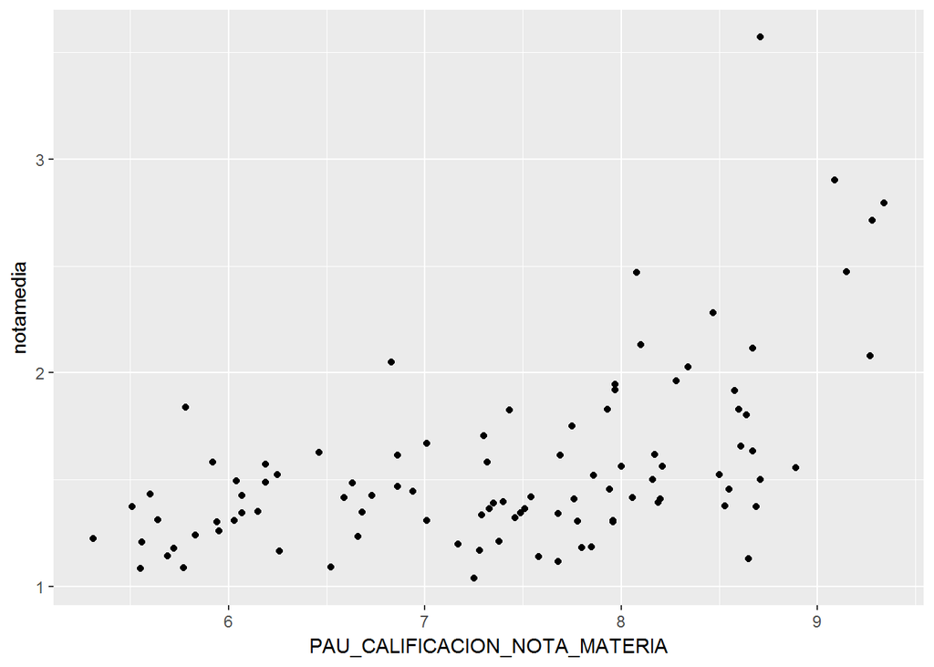

```r
#nota media al terminar en función de la calificación obtenida en PAU al ingresar en la ETSIT
plot <- ggplot(data = GradosTelecoSimple, aes(x = PAU_CALIFICACION_NOTA_MATERIA, y = notamedia))

plot + geom_point()
```

Llevar a cabo la representación gráfica de la nota media al egresar en función del ranking en cuanto a calificación PAU, expresado en decil.

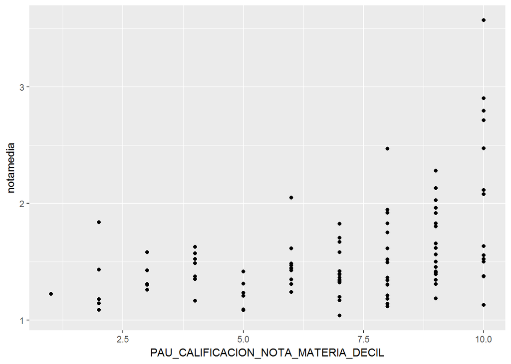

```r
plot <- ggplot(data = GradosTelecoSimple, aes(x = PAU_CALIFICACION_NOTA_MATERIA_DECIL, y = notamedia))

plot + geom_point()
```